# Тест #2

## Вариант #4

**Журавский Максим, группа 520**

```r
library("TSA")
library("tidyverse")
```

Считаем файл с данными о ценах закрытия товаров.

```r
date_format <- col_date("%Y-%m-%d")
stock <- read_delim('Stocks.csv', ',', col_types=cols('Date'=date_format))
stock %>% head()
```

```
## # A tibble: 6 x 8
##   Date          NG   SNP  Gold Brent Light Platinum Silver
##   <date>     <dbl> <dbl> <dbl> <dbl> <dbl>    <dbl>  <dbl>
## 1 2019-02-01  2.73 2707. 1322   62.9  55.4     826.   15.9
## 2 2019-02-04  2.66 2725. 1319.  62.8  54.8     825.   15.9
## 3 2019-02-05  2.70 2738. 1318   62.1  53.7     819.   15.8
## 4 2019-02-06  2.67 2732. 1308.  62.6  53.8     807    15.7
## 5 2019-02-07  2.58 2706. 1313.  61.7  52.3     797.   15.7
## 6 2019-02-08  2.62 2708. 1318.  62.0  52.7     802.   15.8
```

Перейдем к логарифмических доходностям рассматриваемых товаров. При этом мы удалим первое наблюдение, т.к. для него невозможно рассчитать доходность.

```r
calc_rel <- function(x) (x / lag(x))
profit <- stock %>%
  mutate_at(vars(-Date), log) %>%
  mutate_at(vars(-Date), calc_rel) %>%
  slice(-1)
```

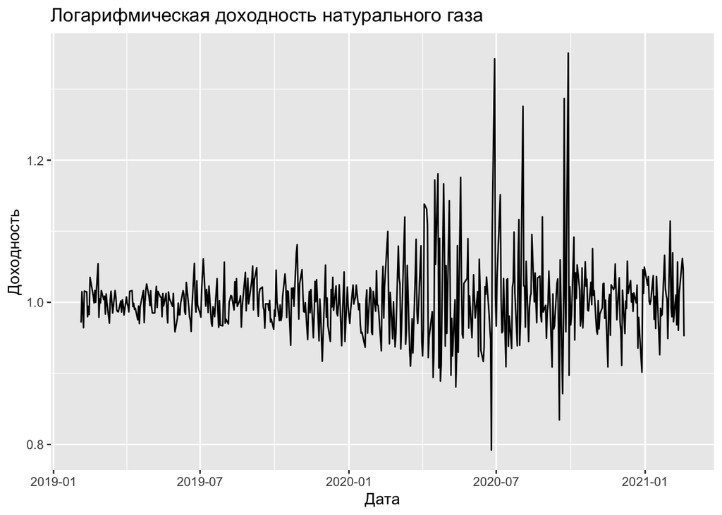

Построим модель линейной регрессии для цены закрытия газа. Для проверки гипотез будем использовать уровень значимости $\alpha = 0.05$.

```r
model <- lm(NG ~ SNP + Gold + Brent + Light + Platinum + Silver + 1, data = profit)
summary(model)
```

```
##
## Call:
## lm(formula = NG ~ SNP + Gold + Brent + Light + Platinum + Silver +
##     1, data = profit)
##
## Residuals:
##      Min       1Q   Median       3Q      Max
## -0.21588 -0.02545 -0.00311  0.02000  0.33620
##
## Coefficients:
##             Estimate Std. Error t value Pr(>|t|)
## (Intercept)  -2.9446     2.4125  -1.221 0.222824
## SNP           1.2996     1.3730   0.947 0.344326
## Gold          0.3605     2.3902   0.151 0.880167
## Brent         1.6442     0.3908   4.207 3.06e-05 ***
## Light        -0.9396     0.2474  -3.797 0.000164 ***
## Platinum      2.4725     1.0661   2.319 0.020774 *
## Silver       -0.8912     0.5321  -1.675 0.094574 .
## ---
## Signif. codes:  0 '***' 0.001 '**' 0.01 '*' 0.05 '.' 0.1 ' ' 1
##
## Residual standard error: 0.05179 on 508 degrees of freedom
## Multiple R-squared:  0.06557,    Adjusted R-squared:  0.05453
## F-statistic: 5.941 on 6 and 508 DF,  p-value: 5.184e-06
```

Заметим, что p-value критерия Фишера (F-test) меньше $\alpha$. Следовательно, гипотеза о том, что выбранные факторы не влияют на целевую переменную, неверна и построенная модель адекватна.

```r
model <- lm(NG ~ Gold + Brent + Light + Platinum + Silver, data = profit)
summary(model)
```

```
##
## Call:
## lm(formula = NG ~ Gold + Brent + Light + Platinum + Silver, data = profit)
##
## Residuals:
##      Min       1Q   Median       3Q      Max
## -0.21565 -0.02569 -0.00332  0.01935  0.33619
##
## Coefficients:
##             Estimate Std. Error t value Pr(>|t|)
## (Intercept)  -1.9525     2.1727  -0.899   0.3693
## Gold          0.2435     2.3868   0.102   0.9188
## Brent         1.7862     0.3609   4.950 1.01e-06 ***
## Light        -0.9738     0.2448  -3.978 7.94e-05 ***
## Platinum      2.8026     1.0073   2.782   0.0056 **
## Silver       -0.9045     0.5318  -1.701   0.0896 .
## ---
## Signif. codes:  0 '***' 0.001 '**' 0.01 '*' 0.05 '.' 0.1 ' ' 1
##
## Residual standard error: 0.05178 on 509 degrees of freedom
## Multiple R-squared:  0.06392,    Adjusted R-squared:  0.05473
## F-statistic: 6.951 on 5 and 509 DF,  p-value: 2.706e-06
```

```r
model <- lm(NG ~ Brent + Light + Platinum + Silver, data = profit)
summary(model)
```

```
##
## Call:
## lm(formula = NG ~ Brent + Light + Platinum + Silver, data = profit)
##
## Residuals:
##      Min       1Q   Median       3Q      Max
## -0.21581 -0.02570 -0.00320  0.01918  0.33611
##
## Coefficients:
##             Estimate Std. Error t value Pr(>|t|)
## (Intercept)  -1.7453     0.7712  -2.263  0.02404 *
## Brent         1.7798     0.3550   5.014 7.37e-07 ***
## Light        -0.9731     0.2444  -3.981 7.86e-05 ***
## Platinum      2.8087     1.0045   2.796  0.00537 **
## Silver       -0.8686     0.3977  -2.184  0.02940 *
## ---
## Signif. codes:  0 '***' 0.001 '**' 0.01 '*' 0.05 '.' 0.1 ' ' 1
##
## Residual standard error: 0.05173 on 510 degrees of freedom
## Multiple R-squared:  0.0639, Adjusted R-squared:  0.05656
## F-statistic: 8.704 on 4 and 510 DF,  p-value: 8.412e-07
```

Таким образом, значимыми предикторами являются доходности нефти Brent и Light, платины и серебра. Незначимыми являются доходности S&P 500 и золота.

Исследуем остатки полученной модели.

```r
residuals <- tibble(Date=profit$Date, Residuals=rstudent(model))
```

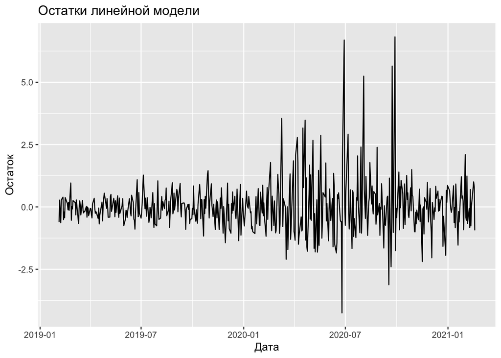

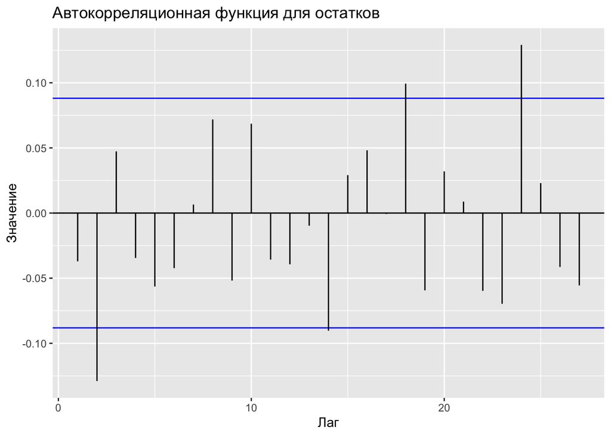

Согласно графикам в остатках модели наблюдается гетероскедестичность. Кроме того, некоторые автокорреляции лежат вне полосы $\frac{±2}{\sqrt{n}}$, следовательно остатки не являются белым шумом. Исследуем распределение остатков.

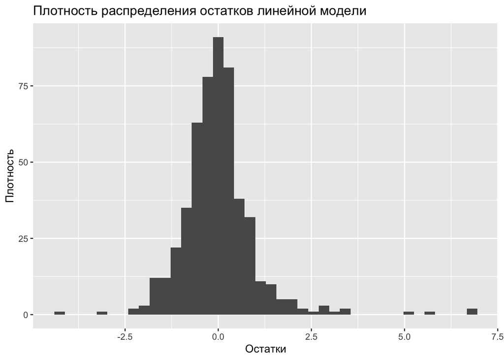

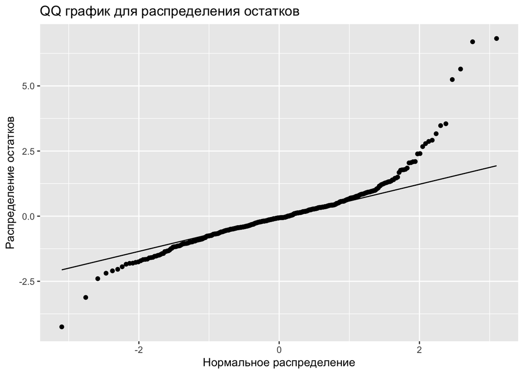

Согласно QQ графику распределение остатков не похоже на нормальное. Проверим наблюдение с помощью теста Шапиро-Вилка:

```r
shapiro.test(residuals$Residuals)
```

```
##
##  Shapiro-Wilk normality test
##
## data:  residuals$Residuals
## W = 0.85964, p-value < 2.2e-16
```

Т.к. p-value для статистики Шапиро-Вилка меньше установленного уровня значимости, гипотеза о нормальности распределения остатков отвергается.